# L’impatto della tecnologia nel mondo della musica

Un analisi di Network Science and Text Mining sugli Spotify Artists & Lyrics

Francesco La Rosa (178327)

2026-08-30

# 1. Introduzione e Quesiti di Ricerca

## 1.1 Contesto e Motivazione del Progetto

L’industria musicale sta attraversando una fase di profonda trasformazione, guidata sia dall’evoluzione tecnologica sia dall’adozione sempre più massiccia dell’IA nel campo produttivo. Inoltre piattaforme di streaming come Spotify non solo hanno cambiato il modo in cui ascoltiamo la musica, ma hanno anche trasformato il mercato in un ecosistema relazionale complesso, plasmato in gran parte da algoritmi di raccomandazione. In parallelo, la tecnologia e l’automazione stanno diventando temi sempre più presenti e discussi all’interno delle opere stesse degli artisti.

Questo progetto nasce dalla volontà di esplorare in modo empirico come le dinamiche sopra citate si riflettano sia sulle relazioni strutturali tra gli artisti, sia sui contenuti semantici che producono. Piuttosto che utilizzare singole tecniche in modo isolato, l’approccio scelto per questa analisi integra due metodologie fondamentali: la **Network Science** e il **Text Mining**.

## 1.2 Domande di Ricerca

Per guidare l’analisi e valutare l’effettivo impatto delle dinamiche discusse, sono state formulate le seguenti domande di ricerca:

1. **Struttura relazionale:** In che modo le collaborazioni (i *featuring*) definiscono le gerarchie e il posizionamento degli artisti nel mercato musicale contemporaneo?
2. **Tematiche latenti:** Come vengono percepiti e raccontati i temi legati al digitale e all’automazione all’interno dei testi musicali?
3. **Intersezione:** Esiste una relazione misurabile tra la centralità di un artista nella rete delle collaborazioni e la sua tendenza a esplorare tematiche tecnologiche nei propri brani?

# 2. Dati Utilizzati: Scelte e Sfide

Per rispondere a queste domande, l’analisi poggia sull’integrazione di due dataset eterogenei e complementari:

## 2.1 I Metadati Musicali: Spotify Tracks Dataset

Questo dataset descrive oltre 100.000 brani. Il campo `artists` permette di ricostruire le co-occorrenze tra musicisti. Sono inoltre disponibili la popolarità e alcune caratteristiche acustiche, tra cui *energy* e *danceability*, utili per descrivere le comunità individuate nella rete.

## 2.2 Il Corpus Testuale: Genius Song Lyrics

Per la parte testuale viene usato Genius, un archivio collaborativo di testi musicali. I testi contengono annotazioni come “[Verse 1]”, punteggiatura irregolare ed espressioni gergali, quindi devono essere puliti. Sul corpus viene poi applicato il modello Latent Dirichlet Allocation (LDA), che individua gruppi di parole ricorrenti. L’eventuale legame con la tecnologia viene valutato solo in un secondo momento.

# 3. Setup dell’Ambiente e Librerie R

## 3.1 Scelta dei Pacchetti

In R, per garantire riproducibilità e performance, si adottano le librerie standard dell’ecosistema Tidyverse e gli strumenti dedicati per grafi e NLP:

- **tidyverse:** Collezione di pacchetti (dplyr, ggplot2, purrr, stringr, readr) che standardizza la manipolazione dei dati tramite sintassi a pipe (%>%).
- **igraph:** fornisce i motori computazionali ad alta velocità per il calcolo delle centralità pesate e per la manipolazione della rete di collaborazioni.
- **ggplot2:** incluso in tidyverse, permette di visualizzare la rete e le metriche prodotte dal grafo.
- **tidytext & topicmodels:** Gestiscono la scomposizione del testo in token e l’addestramento dell’algoritmo di Topic Modeling probabilistico (LDA).
- **corrplot & knitr:** Utilizzati per generare matrici di correlazione visiva tra le metriche di rete e formattare le tabelle riassuntive nel report HTML.

```r
# Caricamento delle librerie nell'ambiente di lavoro
library(tidyverse)    # Manipolazione tabelle e visualizzazione grafici
library(igraph)       # Algoritmi di Network Science (centralità, percorsi)
library(tidytext)     # Tokenizzazione e analisi del testo
library(topicmodels)  # Latent Dirichlet Allocation (LDA)
library(corrplot)     # Visualizzazione matrici di correlazione
library(knitr)        # Generazione tabelle eleganti per HTML
library(scales)       # Formattazione assi numerici e percentuali
library(broom)        # Risultati dei modelli in formato tabellare
library(tinytex)      # Per generare latex e PDF
```

## 3.2 Caricamento del dataset Spotify

Il dataset Spotify viene caricato integralmente. Prima dell’integrazione con Genius vengono controllate le variabili necessarie per la costruzione della rete e per le successive analisi sulla popolarità e sulle caratteristiche acustiche.

```r
  spotify_raw <- read_csv(
    "spotify-tracks-dataset-detailed.csv",
    show_col_types = FALSE
  )

  # Glimpse mostra una sintesi del dataset
  glimpse(spotify_raw)
```

```
## Rows: 114,000
## Columns: 20
## $ track_id         <chr> "5SuOikwiRyPMVoIQDJUgSV", "4qPNDBW1i3p13qLCt0Ki3A", "…
## $ artists          <chr> "Gen Hoshino", "Ben Woodward", "Ingrid Michaelson;ZAY…
## $ album_name       <chr> "Comedy", "Ghost (Acoustic)", "To Begin Again", "Craz…
## $ track_name       <chr> "Comedy", "Ghost - Acoustic", "To Begin Again", "Can'…
## $ popularity       <dbl> 73, 55, 57, 71, 82, 58, 74, 80, 74, 56, 74, 69, 52, 6…
## $ duration_ms      <dbl> 230666, 149610, 210826, 201933, 198853, 214240, 22940…
## $ explicit         <lgl> FALSE, FALSE, FALSE, FALSE, FALSE, FALSE, FALSE, FALS…
## $ danceability     <dbl> 0.676, 0.420, 0.438, 0.266, 0.618, 0.688, 0.407, 0.70…
## $ energy           <dbl> 0.4610, 0.1660, 0.3590, 0.0596, 0.4430, 0.4810, 0.147…
## $ key              <dbl> 1, 1, 0, 0, 2, 6, 2, 11, 0, 1, 8, 4, 7, 3, 2, 4, 2, 1…
## $ loudness         <dbl> -6.746, -17.235, -9.734, -18.515, -9.681, -8.807, -8.…
## $ mode             <dbl> 0, 1, 1, 1, 1, 1, 1, 1, 1, 1, 1, 1, 0, 1, 1, 1, 1, 0,…
## $ speechiness      <dbl> 0.1430, 0.0763, 0.0557, 0.0363, 0.0526, 0.1050, 0.035…
## $ acousticness     <dbl> 0.0322, 0.9240, 0.2100, 0.9050, 0.4690, 0.2890, 0.857…
## $ instrumentalness <dbl> 1.01e-06, 5.56e-06, 0.00e+00, 7.07e-05, 0.00e+00, 0.0…
## $ liveness         <dbl> 0.3580, 0.1010, 0.1170, 0.1320, 0.0829, 0.1890, 0.091…
## $ valence          <dbl> 0.7150, 0.2670, 0.1200, 0.1430, 0.1670, 0.6660, 0.076…
## $ tempo            <dbl> 87.917, 77.489, 76.332, 181.740, 119.949, 98.017, 141…
## $ time_signature   <dbl> 4, 4, 4, 3, 4, 4, 3, 4, 4, 4, 4, 3, 4, 4, 4, 3, 4, 4,…
## $ track_genre      <chr> "acoustic", "acoustic", "acoustic", "acoustic", "acou…
```

```r
  required_spotify_columns <- c(
    "track_id",
    "track_name",
    "artists",
    "popularity",
    "danceability",
    "energy",
    "acousticness",
    "valence"
  )

  # analizzo se le colonne necessaire sono realmente prsenti
  missing_spotify_columns <- setdiff(
    required_spotify_columns,
    names(spotify_raw)
  )

  # Controlla se è stata trovata almeno una colonna mancante.
  # Se tutte sono presenti missing_spotify_columns vuoto e lenght=0
  if (length(missing_spotify_columns) > 0) {

  #Blocca se mancano le colonne necessarie
    stop(
      paste(
        "Nel dataset Spotify mancano le colonne:",
        paste(missing_spotify_columns, collapse = ", ")
      )
    )
  }
```

## 3.3 Data Integration e Normalizzazione

I due dataset non condividono un identificatore univoco. L’unione viene quindi effettuata usando titolo e artista principale. Prima del join vengono eliminate alcune indicazioni accessorie, per esempio “Remastered”, “Live” e “feat.”. La pulizia aumenta il numero di corrispondenze, ma può anche creare falsi abbinamenti; per questo viene mostrato un campione da controllare manualmente.

### 3.3.1 Normalizzazione di titoli e nomi degli artisti

Spotify e Genius non condividono una chiave primaria come un codice ISRC. L’integrazione deve quindi basarsi sulla combinazione fra titolo e artista principale.

Prima del matching vengono rimosse soltanto le informazioni che identificano versioni alternative o collaborazioni, come `feat.`, `remastered`, `live` e `radio edit`. Non viene eliminato indiscriminatamente tutto il contenuto fra parentesi, perché una parentesi può essere parte legittima del titolo.

```r
# Definiamo la funzione che ricevento testo restituisca la versione normalizzata
clean_field <- function(text) {

  # Identifico "(" o "[" che di solito contengono info accerssiorie
  # Alcuni esempi riconosciuti:
  # (feat. Artist)
  # [Live]
  # (Remastered 2011)
  # (Radio Edit)
  # [Acoustic Version]

  #=== Codice generato secondo richiesta per filtro
  removable_parenthetical <- regex(
    paste0(
      "\\s*[\\(\\[][^\\)\\]]*",
      "(feat\\.?|ft\\.?|featuring|remaster(?:ed)?|live|",
      "radio edit|deluxe|version|edit|acoustic|instrumental)",
      "[^\\)\\]]*[\\)\\]]"
    ),
  #=== fine codice generato
    ignore_case = TRUE
  )

  #Converto testo in minuscolo e tolgo valori NA con stringa vuota
  text <- replace_na(text, "")
  text <- str_to_lower(text)

  # Rimuove le parentesi soltanto quando contengono indicazioni accessorie trovate sopra
  text <- str_replace_all(
    text,
    removable_parenthetical,
    " "
  )

  # Rimuove indicazioni di versione collocate dopo un trattino
  # Per esempio:
  # "song title - remastered 2011"
  # diventa:
  # "song title"
  # Consigliato dalla generazione di prima l'integrazione anche di questo
  text <- str_replace_all(
    text,
    regex(
      paste0(
        "\\s+[-–—]\\s+",
        "(remaster(?:ed)?|live|radio edit|deluxe|version|",
        "edit|acoustic|instrumental).*$"
      ),
      ignore_case = TRUE
    ),
    " "
  )

  # Rimuove il featuring quando è inserito alla fine del titolo
  text <- str_replace_all(
    text,
    regex(
      "\\s+(feat\\.?|ft\\.?|featuring)\\s+.*$",
      ignore_case = TRUE
    ),
    " "
  )

  # Uniforma il simbolo & sostituendolo con and
  text <- str_replace_all(text, "&", " and ")

  # Sostituisce la punteggiatura con spazi per evitare duplicati solo per diversa punteggiatura
  text <- str_replace_all(text, "[[:punct:]]", " ")

  # Elimina spazi ripetuti
  text <- str_squish(text)

  return(text)
}
```

## 3.4 Preparazione di Spotify

Per ogni brano viene individuato l’artista principale, corrispondente al primo elemento del campo `artists`. La rete conserverà tutti gli artisti, mentre l’artista principale viene utilizzato esclusivamente per il matching con Genius.

```r
spotify_clean <- spotify_raw %>%
  filter(
    !is.na(track_id),
    !is.na(track_name),
    !is.na(artists)
  ) %>%
  mutate(
    first_artist = str_split_fixed(
      artists,
      ";",
      2
    )[, 1],

    clean_title = clean_field(track_name),
    clean_artist = clean_field(first_artist)
  ) %>%
  filter(
    clean_title != "",
    clean_artist != ""
  )

# Mantiene una sola riga per ogni track_id
spotify_clean <- spotify_clean %>%
  arrange(desc(popularity)) %>%
  distinct(
    track_id,
    .keep_all = TRUE
  )

# Crea l'insieme delle chiavi Spotify utilizzabili per il matching
spotify_keys <- spotify_clean %>%
  distinct(
    clean_title,
    clean_artist
  )

cat(
  "Brani Spotify dopo la pulizia:",
  nrow(spotify_clean),
  "\n"
)
```

```
## Brani Spotify dopo la pulizia: 89738
```

```r
cat(
  "Chiavi titolo-artista Spotify:",
  nrow(spotify_keys),
  "\n"
)
```

```
## Chiavi titolo-artista Spotify: 80126
```

## 3.5 Lettura selettiva del dataset Genius

Il dataset Genius è molto più grande del dataset Spotify. Estrarre un campione casuale prima del matching ridurrebbe fortemente la probabilità di trovare gli stessi brani presenti in Spotify.

Per questo motivo il file Genius viene letto progressivamente a blocchi. In ogni blocco vengono:

1. conservati soltanto i testi classificati come inglesi;
2. normalizzati titolo e artista;
3. conservate soltanto le righe che possiedono una chiave presente in Spotify.

In questo modo viene analizzato l’intero file Genius senza doverlo mantenere interamente in memoria.

```r
genius_matches_list <- list()

genius_callback <- SideEffectChunkCallback$new(
  function(chunk, position) {

    # Verifica che il blocco contenga le colonne necessarie
    required_chunk_columns <- c(
      "title",
      "artist",
      "lyrics",
      "language",
      "language_ft",
      "language_cld3"
    )

    if (!all(required_chunk_columns %in% names(chunk))) {

      stop(
        "Nel dataset Genius mancano una o più colonne necessarie."
      )
    }

    # Conserva soltanto le righe complete
    chunk <- chunk %>%
      filter(
        !is.na(title),
        !is.na(artist),
        !is.na(lyrics)
      )

    # Una riga viene considerata inglese quando almeno uno
    # dei classificatori linguistici la identifica come tale
    chunk <- chunk %>%
      mutate(
        is_english =
          language == "en" |
          language_ft == "en" |
          language_cld3 == "en"
      ) %>%
      filter(
        replace_na(is_english, FALSE)
      )

    # Se il blocco non contiene testi inglesi, passa al blocco successivo
    if (nrow(chunk) == 0) {

      return(invisible(NULL))
    }

    # Normalizzazione delle chiavi Genius
    chunk <- chunk %>%
      mutate(
        clean_title = clean_field(title),
        clean_artist = clean_field(artist)
      ) %>%
      filter(
        clean_title != "",
        clean_artist != "",
        str_length(lyrics) >= 100
      )

    # Conserva soltanto i testi con una chiave presente in Spotify
    chunk <- chunk %>%
      semi_join(
        spotify_keys,
        by = c(
          "clean_title",
          "clean_artist"
        )
      )

    # Aggiunge i risultati del blocco alla lista complessiva
    if (nrow(chunk) > 0) {

      genius_matches_list[[
        length(genius_matches_list) + 1
      ]] <<- chunk
    }

    return(invisible(NULL))
  }
)

# Legge progressivamente tutto il dataset Genius
invisible(
  read_csv_chunked(
    "song_lyrics.csv",
    callback = genius_callback,
    chunk_size = 100000,
    show_col_types = FALSE,
    progress = TRUE
  )
)
# Unisce i risultati provenienti dai diversi blocchi
genius_candidates <- bind_rows(
  genius_matches_list
)

cat(
  "Candidati Genius compatibili con Spotify:",
  nrow(genius_candidates),
  "\n"
)
```

```
## Candidati Genius compatibili con Spotify: 19170
```

## 3.6 De-duplicazione e integrazione Spotify–Genius

Una stessa combinazione titolo-artista può comparire più volte in Genius. Quando sono disponibili più versioni viene conservata quella con il maggior numero di visualizzazioni, utilizzando `views` come criterio di selezione.

```r
if (nrow(genius_candidates) == 0) {

  stop(
    paste(
      "Nessuna corrispondenza Spotify-Genius trovata.",
      "Controllare i nomi dei file e le colonne utilizzate."
    )
  )
}

# De-duplicazione Spotify per la chiave di join
spotify_join <- spotify_clean %>%
  arrange(desc(popularity)) %>%
  distinct(
    clean_title,
    clean_artist,
    .keep_all = TRUE
  )

# De-duplicazione Genius
if ("views" %in% names(genius_candidates)) {

  genius_join <- genius_candidates %>%
    arrange(desc(replace_na(views, 0))) %>%
    distinct(
      clean_title,
      clean_artist,
      .keep_all = TRUE
    )

} else {

  genius_join <- genius_candidates %>%
    distinct(
      clean_title,
      clean_artist,
      .keep_all = TRUE
    )
}

# Join esatto sulle chiavi normalizzate
merged_df <- spotify_join %>%
  inner_join(
    genius_join,
    by = c(
      "clean_title",
      "clean_artist"
    ),
    suffix = c(
      "_spotify",
      "_genius"
    ),
    relationship = "one-to-one"
  ) %>%
  distinct(
    track_id,
    .keep_all = TRUE
  ) %>%
  mutate(
    doc_id = row_number()
  )
```

## 3.7 Valutazione del matching

Il matching rate viene calcolato rispetto alle chiavi Spotify de-duplicate. Viene inoltre mostrato un campione casuale di associazioni per consentire una verifica manuale della qualità.

```r
matching_summary <- tibble(
  indicatore = c(
    "Brani Spotify dopo pulizia",
    "Chiavi Spotify deduplicate",
    "Candidati Genius compatibili",
    "Chiavi Genius deduplicate",
    "Match finali Spotify-Genius",
    "Matching rate rispetto a Spotify"
  ),
  #conta i valori rispettivi e separa le migliaglia
  valore = c(
    format(nrow(spotify_clean), big.mark = "."),
    format(nrow(spotify_join), big.mark = "."),
    format(nrow(genius_candidates), big.mark = "."),
    format(nrow(genius_join), big.mark = "."),
    format(nrow(merged_df), big.mark = "."),
    percent(
      nrow(merged_df) / nrow(spotify_join),
      accuracy = 0.01
    )
  )
)
# Matching summary su tabella formattata
kable(
  matching_summary,
  caption = "Qualità del matching Spotify–Genius"
)
```

Qualità del matching Spotify–Genius

| indicatore | valore |
| --- | --- |
| Brani Spotify dopo pulizia | 89.738 |
| Chiavi Spotify deduplicate | 80.126 |
| Candidati Genius compatibili | 19.170 |
| Chiavi Genius deduplicate | 18.411 |
| Match finali Spotify-Genius | 18.411 |
| Matching rate rispetto a Spotify | 22.98% |

```r
#decido di mostrare solo 30m corrispondenze(se meno mostro tutto)
number_of_matches_to_check <- min(
  30,
  nrow(merged_df)
)

#Dal df con i match finali conservo solo colonne utili e le rinomino in quelle scelte
matching_check <- merged_df %>%
  select(
    titolo_spotify = track_name,
    artista_spotify = first_artist,
    titolo_genius = title,
    artista_genius = artist,
    clean_title,
    clean_artist
  ) %>%
  #ora estraggo in base al numero scelto sopra
  slice_sample(
    n = number_of_matches_to_check
  )

# foormatto per html
kable(
  matching_check,
  caption = "Campione casuale delle corrispondenze Spotify–Genius"
)
```

Campione casuale delle corrispondenze Spotify–Genius

| titolo_spotify | artista_spotify | titolo_genius | artista_genius | clean_title | clean_artist |
| --- | --- | --- | --- | --- | --- |
| Crawl Back In | Dead By Sunrise | Crawl Back In | Dead By Sunrise | crawl back in | dead by sunrise |
| The Philosopher | Death | The Philosopher | Death | the philosopher | death |
| Way Back | Vicetone | Way Back | Vicetone | way back | vicetone |
| My Twin | Katatonia | My Twin | Katatonia | my twin | katatonia |
| Not Enough | Our Lady Peace | Not Enough | Our Lady Peace | not enough | our lady peace |
| My Way | Calvin Harris | My Way | Calvin Harris | my way | calvin harris |
| Chosen Race | Samael | Chosen Race | Samael | chosen race | samael |
| Polaroid Picture | Frank Turner | Polaroid Picture | Frank Turner | polaroid picture | frank turner |
| Blue Jeans | GANGGA | Blue Jeans | GANGGA | blue jeans | gangga |
| Losing It | The Smith Street Band | Losing It | The Smith Street Band | losing it | the smith street band |
| Love Hurts (feat. Toosii) | Lil Tjay | Love Hurts | Lil Tjay | love hurts | lil tjay |
| New Slang | Luke Sital-Singh | New Slang | Luke Sital-Singh | new slang | luke sital singh |
| Something Ah Go Happen | Vybz Kartel | Something Ah Go Happen | Vybz Kartel | something ah go happen | vybz kartel |
| Long | Brazilian Girls | Long | Brazilian Girls | long | brazilian girls |
| Even Angels Cry | Doro | Even Angels Cry | Doro | even angels cry | doro |
| Love To Lose | Sandro Cavazza | Love To Lose | Sandro Cavazza | love to lose | sandro cavazza |
| Little Pixie | Imelda May | Little Pixie | Imelda May | little pixie | imelda may |
| Them Bones (2022 Remaster) | Alice In Chains | Them Bones | Alice in Chains | them bones | alice in chains |
| Be Somebody | Thousand Foot Krutch | Be Somebody | Thousand Foot Krutch | be somebody | thousand foot krutch |
| Angels (Singing Gloria) | Matt Redman | Angels Singing Gloria | Matt Redman | angels singing gloria | matt redman |
| Monster | Skillet | Monster | Skillet | monster | skillet |
| Scream | Blind Channel | Scream | Blind Channel | scream | blind channel |
| I Feel It Coming | The Weeknd | I Feel It Coming | The Weeknd | i feel it coming | the weeknd |
| The Radiance | It Dies Today | The Radiance | It Dies Today | the radiance | it dies today |
| My Friends | Red Hot Chili Peppers | My Friends | Red Hot Chili Peppers | my friends | red hot chili peppers |
| Every Time You Leave | I Prevail | Every Time You Leave | I Prevail | every time you leave | i prevail |
| The Drapery Falls | Opeth | The Drapery Falls | Opeth | the drapery falls | opeth |
| Five Little Monkeys | Mother Goose Club | Five Little Monkeys | Mother Goose Club | five little monkeys | mother goose club |
| The Night We Met | Lord Huron | The Night We Met | Lord Huron | the night we met | lord huron |
| Ball And Chain (Honky Tonk) | Mike Ness | Ball and Chain Honky Tonk | Mike Ness | ball and chain honky tonk | mike ness |

La qualità del matching viene valutata sia attraverso il numero complessivo di corrispondenze sia mediante l’ispezione manuale del campione riportato. L’analisi testuale viene considerata esplorativa quando il numero di testi allineati rimane contenuto.

# 4. Network Science: Rete delle Collaborazioni

## 4.1 Modellazione del Grafico

La rete viene modellata come un grafo non orientato e pesato $G = (V, E, W)$ dove:

- **Nodi (**$V$): Rappresentano i singoli artisti.
- **Archi (**$E$): Rappresentano una collaborazione certificata in almeno un brano.
- **Pesi (**$W$): il peso $w_{ij}$ corrisponde al numero di brani nei quali gli artisti $i$ e $j$ compaiono insieme.

La relazione viene quindi interpretata come una co-occorrenza nei crediti Spotify. Nella musica contemporanea essa corrisponde frequentemente a un featuring o a una collaborazione diretta. Nel caso della musica classica, di raccolte o reinterpretazioni, può invece rappresentare la relazione fra compositore, interprete, orchestra o altri soggetti accreditati.

L’uso dei pesi permette di distinguere le associazioni occasionali dalle relazioni ripetute. Una coppia di artisti presente in numerosi brani avrà quindi un arco più forte rispetto a una coppia presente in un solo brano.

## 4.2 Analisi delle Centralità e Primi Risultati

L’applicazione delle metriche di Network Science ha lo scopo di tradurre la topografia del grafico in ruoli strutturali concreti all’interno del settore musicale:

- **Weighted Degree (Strength)**: somma i pesi degli archi di un artista e misura il volume delle sue co-occorrenze.
- **Betweenness Centrality**: identifica i nodi che si trovano spesso nei cammini minimi. Per ridurre i tempi di calcolo viene stimata soltanto sul nucleo dei 2.500 artisti con Strength maggiore. Nel report è quindi chiamata `core_betweenness` e non rappresenta l’intera rete.
- **PageRank**: assegna un valore più alto ai nodi collegati ad altri nodi importanti. Non misura la qualità artistica, ma soltanto la posizione nella rete.
- **Louvain**: divide la rete in comunità con molti collegamenti interni e meno collegamenti esterni. Le comunità possono riflettere generi, lingue o mercati musicali, ma questa interpretazione deve essere controllata osservando gli artisti presenti in ciascun gruppo.

```r
# Estrazione di tutte le coppie uniche di artisti per ogni brano

# creo una tabella con una riga per ogni artista di ogni brano.
track_artists_long <- spotify_clean %>%
  mutate(track_row = row_number()) %>%
  select(track_row, track_id, artists) %>%
  separate_longer_delim(artists, delim = ";") %>%
  mutate(artist_clean = clean_field(artists)) %>%
  filter(artist_clean != "") %>%
  distinct(track_row, artist_clean)

# genero tutte le coppie di artisti dello stesso brano
collaboration_pairs <- inner_join(
  track_artists_long,
  track_artists_long,
  by = "track_row",
  relationship = "many-to-many"
) %>%
  #dopo il self joia abbiamo a,b e b,a, quindi la condizione < conserva solo una direzione ed elimina a,a
  filter(artist_clean.x < artist_clean.y) %>%
  # creo la tabella fronìm a to b
  transmute(
    from = artist_clean.x,
    to = artist_clean.y
  )

#conto quante volte compare ogni coppia e lo salvo su weight
collaborations <- collaboration_pairs %>%
  count(from, to, name = "weight") %>%
  filter(from != to) # risetto filtro a<b solo per sicurezza

# Creazione dell'oggetto igraph non orientato
net_graph <- graph_from_data_frame(
  d = collaborations,
  directed = FALSE #not oriented: a->b == b->a
)

E(net_graph)$weight <- collaborations$weight #assegno agli archi i pesi

cat("Topologia della Rete:\n")
```

```
## Topologia della Rete:
```

```r
cat("- Numero di nodi (Artisti):", vcount(net_graph), "\n")
```

```
## - Numero di nodi (Artisti): 19655
```

```r
cat("- Numero di archi (Collaborazioni):", ecount(net_graph), "\n")
```

```
## - Numero di archi (Collaborazioni): 38670
```

```r
# Strength / Grado Pesato
weighted_degree <- strength(
  net_graph,
  mode = "all",
  weights = E(net_graph)$weight
)

# PageRank ponderato
weighted_pagerank <- page_rank(
  net_graph,
  directed = FALSE,
  weights = E(net_graph)$weight
)$vector #estragggo solo il punteggio

# Algoritmo di Louvain per clustering della rete
louvain_model <- cluster_louvain(
  net_graph,
  weights = E(net_graph)$weight
)

# Betweenness pesata calcolata sul nucleo piu' collaborativo per evitare tempi eccessivi
core_artists_for_betweenness <- names(sort(weighted_degree, decreasing = TRUE)) %>%
  head(2500)
#costruisco sottografo limitato ai 2500 artisti selezionati
core_graph_for_betweenness <- induced_subgraph(
  net_graph,
  vids = V(net_graph)$name %in% core_artists_for_betweenness
)
# Calcola la betweenness nel sottografo
core_betweenness <- betweenness(
  core_graph_for_betweenness,
  directed = FALSE,
  weights = 1 / E(core_graph_for_betweenness)$weight,#igraph interpreta pesi come distanze, ma nel nostro proj peso alto=relazione forte quindi devo fare reciproco
  normalized = TRUE
)

weighted_betweenness <- rep(NA_real_, vcount(net_graph)) #setto na per gli artisti esterni
names(weighted_betweenness) <- V(net_graph)$name
weighted_betweenness[names(core_betweenness)] <- as.numeric(core_betweenness)

# Estrazione del dataframe dei nodi per analisi tabulari e join successivi
nodes_summary <- tibble(
  name = names(weighted_degree),
  weighted_degree = as.numeric(weighted_degree),
  core_betweenness = as.numeric(weighted_betweenness),
  pagerank = as.numeric(weighted_pagerank),
  community = as.factor(membership(louvain_model))
) %>%
  arrange(desc(weighted_degree))

# Visualizziamo i 10 artisti più centrali per Weighted Degree
kable(head(nodes_summary, 10), digits = 5, caption = "Top 10 Artisti per Volume di Collaborazioni (Strength)")
```

Top 10 Artisti per Volume di Collaborazioni (Strength)

| name | weighted_degree | core_betweenness | pagerank | community |
| --- | --- | --- | --- | --- |
| pritam | 627 | 0.10342 | 0.00195 | 35 |
| wolfgang amadeus mozart | 557 | 0.02912 | 0.00184 | 126 |
| arijit singh | 441 | 0.05620 | 0.00133 | 35 |
| giuseppe verdi | 335 | 0.06150 | 0.00094 | 126 |
| giacomo puccini | 284 | 0.07201 | 0.00075 | 126 |
| traditional | 255 | 0.09929 | 0.00090 | 67 |
| luciano pavarotti | 253 | 0.03121 | 0.00067 | 126 |
| hans zimmer | 252 | 0.01363 | 0.00065 | 142 |
| j balvin | 245 | 0.11997 | 0.00085 | 15 |
| berliner philharmoniker | 220 | 0.04194 | 0.00053 | 126 |

## 4.3 Correlazione tra le misure di centralità

Le centralità di una rete musicale presentano normalmente distribuzioni fortemente asimmetriche: molti artisti possiedono valori bassi, mentre pochi hub raggiungono valori molto elevati. Per questa ragione viene utilizzata la correlazione di rango di Spearman, meno sensibile ai valori estremi e adatta a relazioni monotone non necessariamente lineari.

La correlazione viene calcolata soltanto sugli artisti appartenenti al nucleo utilizzato per la `core_betweenness`.

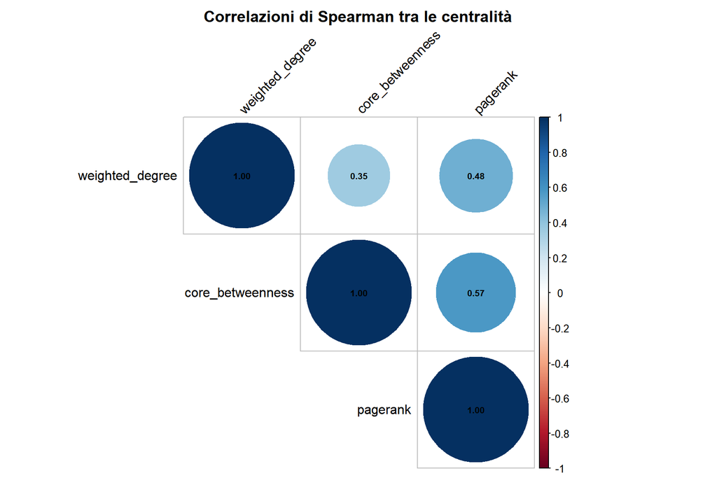

```r
#tabella Nodes_summary con misure di centralità xogni artista per cui disp core_betw (2500)
cor_data <- nodes_summary %>%
  filter(
    !is.na(core_betweenness)
  ) %>%
  select( #conservo solo le 3 di cui voglio confronto
    weighted_degree,
    core_betweenness,
    pagerank
  )

cor_matrix <- cor(
  cor_data,
  use = "pairwise.complete.obs", #Calcola correlazione usando tutte coppie valori disponibili per le due variabili considerate per evitare che val mancante elimini la riga da altre correlazioni
  method = "spearman"
)

corrplot(
  cor_matrix,
  method = "circle",
  type = "upper",
  addCoef.col = "black",
  number.cex = 0.66,
  tl.col = "black",
  tl.srt = 45,
  title = "Correlazioni di Spearman tra le centralità",
  mar = c(0, 0, 2, 0)
)
```

Valori elevati indicano che le metriche tendono a ordinare gli artisti in modo simile. Una correlazione inferiore suggerisce invece che le metriche catturano ruoli strutturali differenti: la Strength misura il volume delle collaborazioni, PageRank considera l’autorevolezza dei vicini e la `core_betweenness` individua possibili intermediari nel nucleo della rete.

## 4.4 Visualizzazione Grafica della Rete

Per rendere leggibile il grafo, estraiamo la componente connessa principale o filtriamo i nodi con una soglia minima di grado pesato prima del rendering

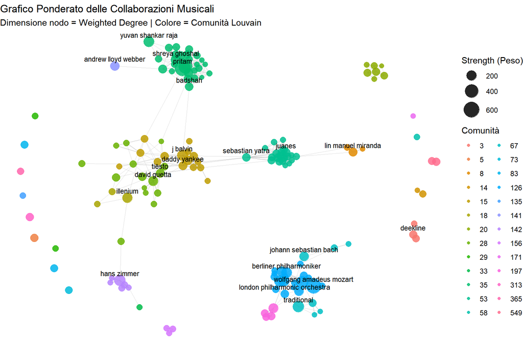

```r
# Filtriamo un sottografo per evidenziare il nucleo centrale (150 artisti con maggiore strenght)
top_artists_for_plot <- nodes_summary %>%
  slice_max(weighted_degree, n = 150) %>%
  pull(name)

#Creo ora un sottografo con solo gli artisti precedentemente selezionati e i relativi archi
sub_graph <- induced_subgraph(
  net_graph,
  vids = V(net_graph)$name %in% top_artists_for_plot
)

#Ora filtro lemetriche per i soli nodi del sottografo
plot_node_metrics <- nodes_summary %>%
  filter(name %in% V(sub_graph)$name)

#Assegno Weighted e Community ai vertici per ottenere un ordine tramite match()
V(sub_graph)$weighted_degree <- plot_node_metrics$weighted_degree[
  match(V(sub_graph)$name, plot_node_metrics$name)
]
V(sub_graph)$community <- plot_node_metrics$community[
  match(V(sub_graph)$name, plot_node_metrics$name)
]

#Assegno il layout con Fruchterman-Reingold pesato sui pesi degli archi
layout_matrix <- layout_with_fr(sub_graph, weights = E(sub_graph)$weight)

#Converto matrix delle coordinate e vi associo i metadati del nodo
node_positions <- as_tibble(layout_matrix, .name_repair = "minimal") %>%
  set_names(c("x", "y")) %>%
  mutate(
    name = V(sub_graph)$name,
    weighted_degree = V(sub_graph)$weighted_degree,
    community = V(sub_graph)$community
  )

#Estaggo archi e unisco x y tramite join (da from a to)
edge_positions <- as_data_frame(sub_graph, what = "edges") %>%
  left_join(node_positions %>% select(name, x, y), by = c("from" = "name")) %>%
  rename(x_from = x, y_from = y) %>%
  left_join(node_positions %>% select(name, x, y), by = c("to" = "name")) %>%
  rename(x_to = x, y_to = y)

#Funzione di render
ggplot() +
  geom_segment( #Proporziono gli archi al peso della collabo
    data = edge_positions,
    aes(x = x_from, y = y_from, xend = x_to, yend = y_to, linewidth = weight),
    alpha = 0.35,
    color = "gray60"
  ) +
  geom_point( #Proporziono i nodi con dimensione in base strwenght e colore dato da community
    data = node_positions,
    aes(x = x, y = y, size = weighted_degree, color = community),
    alpha = 0.85
  ) +
  geom_text(#print solo i 20 nodi principali per evitare overlap
    data = node_positions %>% slice_max(weighted_degree, n = 35),
    aes(x = x, y = y, label = name),
    size = 3,
    vjust = -0.8,
    check_overlap = TRUE
  ) +
  scale_linewidth(range = c(0.3, 1.8), guide = "none") +
  scale_size(range = c(2.5, 9)) +
  theme_void() +
  labs(
    title    = "Grafico Ponderato delle Collaborazioni Musicali",
    subtitle = "Dimensione nodo = Weighted Degree | Colore = Comunità Louvain",
    size     = "Strength (Peso)",
    color    = "Comunità"
  )
```

## 4.5 Profilo Musicale delle Comunità

Per evitare di attribuire alle community Louvain significati non verificati, descriviamo i gruppi principali usando gli artisti più centrali e le caratteristiche Spotify medie dei brani associati agli artisti primari. Questo sistema ci permette di stimare i generi delle community, seppur in maniera abbastanza artificiosa.

```r
community_labels <- nodes_summary %>%
  arrange(community,
          desc(weighted_degree)
          ) %>%
  # Ordino 1a artisti per community poi dentro dalla Strength > alla <

  group_by(community) %>%
  summarise( #Creo una riga riassuntiva per ogni community
    top_artists = paste(
      head(name, 4),
      collapse = ", "
      ),#con questo creo una striga con 4 nomi separati da ,
    artists_in_community = n(),
    .groups = "drop" #elimino raggrupp
  )

spotify_artist_tracks <- spotify_clean %>%
  left_join(nodes_summary, by = c("clean_artist" = "name")) %>% #clean è art principale
  filter(!is.na(community)) #e lascio solo dove esso è nella rete e possiede community

community_music_profile <- spotify_artist_tracks %>%
  group_by(community) %>%
  summarise(
    brani_spotify = n_distinct(track_id), #conto i brani distinti associati

    popularity_media = mean(popularity, na.rm = TRUE),
    danceability_media = mean(danceability, na.rm = TRUE),
    energy_media = mean(energy, na.rm = TRUE),
    acousticness_media = mean(acousticness, na.rm = TRUE),
    valence_media = mean(valence, na.rm = TRUE),
    .groups = "drop"
  ) %>%
  # Aggiunge alla tabella 4 artisti principali e n di artisti nel community poi ordino in base > n di brani
  left_join(community_labels, by = "community") %>%
  arrange(desc(brani_spotify))


#con questo tengo solo le 15 comm princ
community_music_profile_top <- head(community_music_profile, 15)

#arrotonda le medie a tre cifre decimali
community_music_profile_top$brani_spotify <- round(community_music_profile_top$brani_spotify, 3) #inutile dato che a n intero... da togliere
community_music_profile_top$popularity_media <- round(community_music_profile_top$popularity_media, 3)
community_music_profile_top$danceability_media <- round(community_music_profile_top$danceability_media, 3)
community_music_profile_top$energy_media <- round(community_music_profile_top$energy_media, 3)
community_music_profile_top$acousticness_media <- round(community_music_profile_top$acousticness_media, 3)
community_music_profile_top$valence_media <- round(community_music_profile_top$valence_media, 3)

kable(
  community_music_profile_top,
  caption = "Profilo musicale descrittivo delle principali community Louvain"
)
```

Profilo musicale descrittivo delle principali community Louvain

| community | brani_spotify | popularity_media | danceability_media | energy_media | acousticness_media | valence_media | top_artists | artists_in_community |
| --- | --- | --- | --- | --- | --- | --- | --- | --- |
| 15 | 4778 | 34.709 | 0.677 | 0.693 | 0.189 | 0.534 | j balvin, bad bunny, daddy yankee, dj snake | 982 |
| 28 | 4155 | 37.746 | 0.636 | 0.707 | 0.166 | 0.457 | david guetta, tiësto, martin garrix, armin van buuren | 1145 |
| 14 | 3102 | 41.325 | 0.580 | 0.697 | 0.477 | 0.655 | ferrugem, suel, rdn, baianasystem | 476 |
| 35 | 2855 | 50.876 | 0.611 | 0.614 | 0.435 | 0.525 | pritam, arijit singh, yuvan shankar raja, shreya ghoshal | 1058 |
| 18 | 1525 | 42.799 | 0.545 | 0.697 | 0.197 | 0.323 | illenium, slander, seven lions, dabin | 548 |
| 13 | 1368 | 34.439 | 0.688 | 0.712 | 0.081 | 0.340 | bassnectar, solomun, aaron smith, virtual riot | 501 |
| 3 | 1301 | 26.809 | 0.600 | 0.840 | 0.057 | 0.421 | deekline, ed solo, dub pistols, chase and status | 595 |
| 11 | 1205 | 25.217 | 0.542 | 0.893 | 0.079 | 0.292 | jebroer, neophyte, brennan heart, paul elstak | 438 |
| 126 | 1005 | 16.602 | 0.339 | 0.198 | 0.913 | 0.294 | wolfgang amadeus mozart, giuseppe verdi, giacomo puccini, luciano pavarotti | 686 |
| 20 | 936 | 42.229 | 0.649 | 0.663 | 0.303 | 0.583 | mc ryan sp, mc kadu, mc ig, mc joãozinho vt | 471 |
| 125 | 896 | 38.704 | 0.470 | 0.586 | 0.348 | 0.333 | fernandinho, ana paula valadão, cassiane, nívea soares | 210 |
| 156 | 842 | 15.116 | 0.727 | 0.735 | 0.058 | 0.554 | frankie knuckles, director s cut, eric kupper, kevin saunderson | 292 |
| 53 | 838 | 30.693 | 0.615 | 0.670 | 0.300 | 0.589 | juanes, sebastian yatra, david bisbal, pablo alborán | 240 |
| 8 | 832 | 38.141 | 0.618 | 0.667 | 0.284 | 0.542 | lin manuel miranda, anthony ramos, original broadway cast of hamilton, luis fonsi | 220 |
| 67 | 811 | 23.435 | 0.432 | 0.352 | 0.690 | 0.414 | traditional, johann sebastian bach, rolando villazón, daniel hope | 268 |

# 5. Text Mining e Topic Modeling

## 5.1 Definizione e pulizia del corpus

L’analisi testuale usa soltanto i brani inglesi che è stato possibile collegare tra Spotify e Genius. Limitarsi a una lingua riduce il rischio che LDA separi i testi solamente in base alla lingua anziché al contenuto.

Prima della tokenizzazione vengono rimossi gli elementi editoriali più comuni di Genius: intestazioni tra parentesi quadre, link e parole come `Embed`.

```r
#== generato da Chatgpt per pulizia di intestazioni "dato il progetto trovami il modo di rimuovere le parti del dataset GEnius che presentano link e altre aggiunte tipiche di esso, scrivi in R"

lyrics_docs <- merged_df %>%
  distinct(
    track_id,
    .keep_all = TRUE
  ) %>%
  mutate(
    clean_lyrics = lyrics %>%
      str_remove_all("\\[[^]]*\\]") %>%
      str_remove_all("https?://\\S+|www\\.\\S+") %>%
      str_remove_all(
        regex(
          "you might also like|embed",
          ignore_case = TRUE
        )
      ) %>%
      str_to_lower() %>%
      str_squish()
  ) %>%
  select(
    doc_id,
    track_id,
    track_name,
    artists,
    first_artist,
    clean_artist,
    popularity,
    track_genre,
    danceability,
    energy,
    acousticness,
    valence,
    clean_lyrics
  ) %>%
  filter(
    !is.na(clean_lyrics),
    str_length(clean_lyrics) >= 200
  )

cat(
  "Documenti disponibili prima della tokenizzazione:",
  nrow(lyrics_docs),
  "\n"
)
```

```
## Documenti disponibili prima della tokenizzazione: 18195
```

## 5.2 Tokenizzazione e rimozione delle stopword

Alle stopword inglesi standard vengono aggiunte alcune intestazioni e vocalizzazioni frequenti nei testi. Queste parole sono state escluse perché compaiono spesso ma non descrivono il tema di un brano.

```r
#Sfrutto il codice precedentemente generato, modificandolo per quello che mi serve per questo caso
custom_stop_words <- tibble(
  word = c(
    "verse",
    "chorus",
    "bridge",
    "intro",
    "outro",
    "lyrics",
    "embed",
    "yeah",
    "ooh",
    "ohh",
    "ayy",
    "aye",
    "uhh",
    "whoa",
    "woah",
    "gonna",
    "wanna",
    "gotta",
    "cause",
    "repeat",
    "ye",
    "brr"
  )
)

all_stop_words <- stop_words %>%
  select(word) %>%
  bind_rows(custom_stop_words) %>%
  distinct(word)

lyrics_tokens <- lyrics_docs %>%
  select(
    doc_id,
    clean_lyrics
  ) %>%
  unnest_tokens(
    word,
    clean_lyrics,
    token = "words"
  ) %>%
  filter(
    str_detect(word, "^[a-z]+$"),
    str_length(word) >= 3,
    str_length(word) <= 25
  ) %>%
  anti_join(
    all_stop_words,
    by = "word"
  )
```

## 5.3 Frequenza documentale e Document-Term Matrix

Le parole presenti in meno di cinque testi vengono eliminate perché sono troppo rare per descrivere temi ricorrenti. Se il corpus contiene meno di 100 testi, la soglia viene ridotta a tre. Vengono inoltre rimosse le parole presenti in oltre l’80% dei testi, perché distinguono poco i documenti.

Queste soglie sono scelte operative adatte a questo corpus e non valori obbligatori per ogni analisi LDA.

```r
#Conto numero di testi dopo tokeniz
number_of_documents <- n_distinct(
  lyrics_tokens$doc_id
)
#stabilisco una frequenza minima per una parola 5:100
minimum_document_frequency <- if_else(
  number_of_documents >= 100,
  5,
  3
)
#Calcolo in quanti doc compare la parola tenendo una sola occorrenza per doc (se x viene citato anche 10 volte nella stassa canzone lo conto 1 per documento)
document_frequency <- lyrics_tokens %>%
  distinct(
    doc_id,
    word
  ) %>%
  count(
    word,
    name = "documents_with_word"
  )

# Seleziona le parole considerate utili per l'analisi.
valid_words <- document_frequency %>%
  filter(
    documents_with_word >= minimum_document_frequency,
    documents_with_word <= 0.80 * number_of_documents #estraggo quelle troppo usate
  ) %>%
  pull(word)

#tab con solo parole filtrate
lyrics_tokens_filtered <- lyrics_tokens %>%
  filter(
    word %in% valid_words # %in% controlla se ogni parola è nell elenco valid_words
  ) %>%
  count( # Conta quante volte ogni parola compare in ciascun documento
    doc_id,
    word,
    name = "n"
  )
# Trasforma la tabella in una Document-Term Matrix dove righe =nome documenti e colonne =parole celle numero di occorrenze della parola
dtm <- lyrics_tokens_filtered %>%
  cast_dtm(
    document = doc_id,
    term = word,
    value = n
  )

dtm_summary <- tibble(
  metrica = c(
    "Documenti originali",
    "Documenti nella DTM",
    "Termini nella DTM",
    "Celle non nulle",
    "Frequenza documentale minima"
  ),
  valore = c(
    nrow(lyrics_docs),
    nrow(dtm),
    ncol(dtm),
    length(dtm$v),
    minimum_document_frequency
  )
)

kable(
  dtm_summary,
  caption = "Caratteristiche della Document-Term Matrix"
)
```

Caratteristiche della Document-Term Matrix

| metrica | valore |
| --- | --- |
| Documenti originali | 18195 |
| Documenti nella DTM | 18181 |
| Termini nella DTM | 12806 |
| Celle non nulle | 714012 |
| Frequenza documentale minima | 5 |

```r
if (nrow(dtm) < 30) {
  stop("La DTM contiene meno di 30 documenti: il corpus è troppo piccolo per questa analisi.")
}

if (ncol(dtm) < 50) {
  stop("La DTM contiene meno di 50 termini: il vocabolario è troppo piccolo per questa analisi.")
}
```

## 5.4 Scelta del numero di topic

I documenti vengono divisi casualmente in training set (80%) e test set (20%). Per ogni valore candidato di (k), LDA viene addestrato sul training set e valutato sul test set tramite perplexity. Un valore più basso indica una migliore capacità di rappresentare documenti non usati nell’addestramento.

La perplexity seleziona soltanto il risultato migliore tra i valori provati. In questo caso diminuisce fino a (k=10), che è anche il massimo candidato: non è quindi possibile affermare che 10 sia il numero ottimale in assoluto. La leggibilità dei topic deve essere controllata dopo la stima.

```r
# Recuperiamo i nomi identificativi di tutti i documenti presenti nella DTM
all_document_names <- dimnames(dtm)$Docs

# Calcoliamo quanti documenti utilizzare per il training set.
# L'80% dei documenti viene utilizzato per addestrare LDA.
training_size <- floor(
  0.80 * length(all_document_names)
)

# Estraiamo casualmente i documenti del training set
training_document_names <- sample(
  all_document_names,
  size = training_size,
  replace = FALSE
)

# I documenti non selezionati per il training formano il test set
test_document_names <- setdiff(
  all_document_names,
  training_document_names
)

# Creiamo la DTM di training selezionando le righe corrispondenti
training_dtm <- dtm[
  training_document_names,
]

# Creiamo la DTM di test selezionando le righe rimanenti
test_dtm <- dtm[
  test_document_names,
]

training_test_summary <- tibble(
  insieme = c("Training set", "Test set"),
  documenti = c(nrow(training_dtm), nrow(test_dtm)),
  percentuale = c(nrow(training_dtm), nrow(test_dtm)) / nrow(dtm)
)

kable(
  training_test_summary,
  digits = 3,
  caption = "Divisione dei documenti fra training set e test set"
)
```

Divisione dei documenti fra training set e test set

| insieme | documenti | percentuale |
| --- | --- | --- |
| Training set | 14544 | 0.8 |
| Test set | 3637 | 0.2 |

```r
candidate_k <- c(3, 4, 5, 6, 8, 10)

# Il numero di topic non può essere eccessivo rispetto ai documenti
candidate_k <- candidate_k[
  candidate_k < nrow(training_dtm)
]

lda_comparison <- tibble(
  k = candidate_k,
  perplexity = NA_real_
)

for (i in seq_along(candidate_k)) {
  current_model <- LDA(
    training_dtm,
    k = candidate_k[i],
    method = "Gibbs",
    control = list(seed = 1234, burnin = 500, iter = 1500, thin = 100)
  )

  lda_comparison$perplexity[i] <- perplexity(
    current_model,
    newdata = test_dtm
  )
}

kable(
  lda_comparison,
  digits = 2,
  caption = "Confronto del numero di topic mediante perplexity"
)
```

Confronto del numero di topic mediante perplexity

| k | perplexity |
| --- | --- |
| 3 | 2063.11 |
| 4 | 1979.58 |
| 5 | 1914.36 |
| 6 | 1844.59 |
| 8 | 1742.96 |
| 10 | 1659.56 |

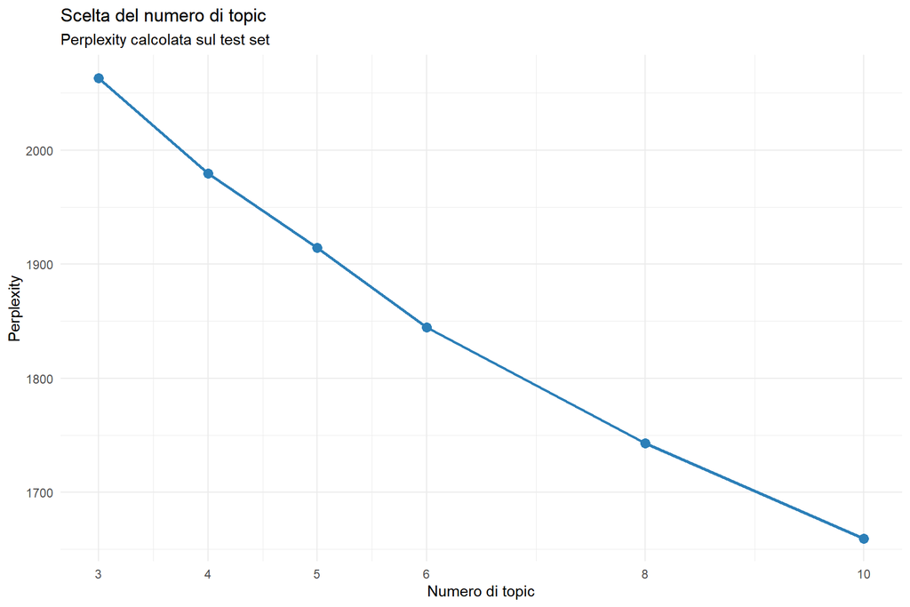

```r
ggplot(
  lda_comparison,
  aes(
    x = k,
    y = perplexity
  )
) +
  geom_line(
    linewidth = 1,
    color = "#2C7FB8"
  ) +
  geom_point(
    size = 3,
    color = "#2C7FB8"
  ) +
  scale_x_continuous(
    breaks = candidate_k
  ) +
  theme_minimal() +
  labs(
    title = "Scelta del numero di topic",
    subtitle = "Perplexity calcolata sul test set",
    x = "Numero di topic",
    y = "Perplexity"
  )
```

## 5.5 Addestramento del modello definitivo

Il numero di topic con la perplexity più bassa (k) viene utilizzato per addestrare il modello definitivo sull’intera DTM.

```r
selected_k <- lda_comparison %>%
  slice_min(
    perplexity,
    n = 1,
    with_ties = FALSE
  ) %>%
  pull(k)

cat(
  "Numero di topic selezionato:",
  selected_k,
  "\n"
)
```

```
## Numero di topic selezionato: 10
```

```r
set.seed(1234)

lda_model <- LDA(
  dtm,
  k = selected_k,
  method = "Gibbs",
  control = list(
    seed = 1234,
    burnin = 1000,
    iter = 2000,
    thin = 100
  )
)

topic_beta <- tidy(
  lda_model,
  matrix = "beta"
)

topic_gamma <- tidy(
  lda_model,
  matrix = "gamma"
)
```

## 5.6 Interpretazione dei topic

Il parametro $\beta$ rappresenta la probabilità di una parola dato un topic:

$$\beta_{kw}=P(w\mid k)$$

Le parole con $\beta$ maggiore aiutano a interpretare il contenuto del topic, ma l’etichetta finale richiede una valutazione manuale.

```r
topic_terms <- topic_beta %>%
  group_by(topic) %>%
  slice_max(beta, n = 15, with_ties = FALSE) %>%
  ungroup() %>%
  arrange(topic, desc(beta))

topic_terms_table <- topic_terms %>%
  group_by(topic) %>%
  summarise(top_terms = paste(term, collapse = ", "), .groups = "drop")

kable(
  topic_terms_table,
  caption = "Le quindici parole più caratteristiche di ciascun topic"
)
```

Le quindici parole più caratteristiche di ciascun topic

| topic | top_terms |
| --- | --- |
| 1 | god, fire, free, soul, stand, burn, lord, death, heaven, fight, set, power, born, fear, earth |
| 2 | head, stop, break, hands, dead, hate, bring, rock, hell, fucking, sound, watch, kill, ground, cut |
| 3 | heart, left, lost, forever, hope, remember, cry, words, pain, walk, found, start, save, doo, broken |
| 4 | home, coming, cold, black, christmas, rain, blue, red, road, ride, hear, moon, water, wind, white |
| 5 | time, life, night, day, mind, stay, tonight, live, leave, feeling, change, die, days, sleep, feels |
| 6 | world, eyes, light, fall, inside, dream, wait, waiting, sun, dark, close, deep, alive, running, lose |
| 7 | hey, call, hard, play, people, friends, round, care, song, happy, sing, friend, girls, music, city |
| 8 | love, baby, feel, girl, hold, mine, bad, alright, true, lie, sweet, fine, kiss, heart, touch |
| 9 | fuck, shit, bitch, ready, hit, nigga, gon, boy, money, bout, real, niggas, damn, huh, tryna |
| 10 | run, dem, dance, yuh, move, body, nah, nuh, gyal, shake, inna, woman, pon, beat, dey |

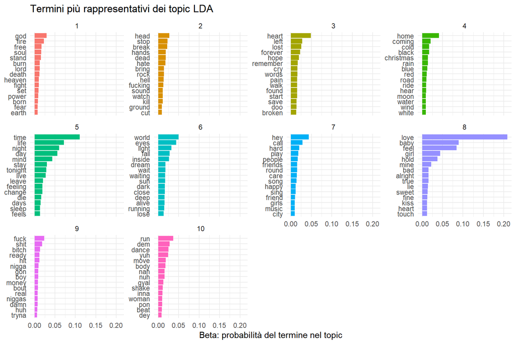

```r
topic_terms %>%
  mutate(
    term = reorder_within(
      term,
      beta,
      topic
    )
  ) %>%
  ggplot(
    aes(
      x = beta,
      y = term,
      fill = factor(topic)
    )
  ) +
  geom_col(
    show.legend = FALSE
  ) +
  scale_y_reordered() +
  facet_wrap(
    ~ topic,
    scales = "free_y"
  ) +
  theme_minimal() +
  labs(
    title = "Termini più rappresentativi dei topic LDA",
    x = "Beta: probabilità del termine nel topic",
    y = NULL
  )
```

Le etichette dei topic vengono costruite utilizzando le quattro parole più caratteristiche. Tali etichette hanno una funzione descrittiva e non sostituiscono l’interpretazione semantica del ricercatore.

```r
topic_labels <- topic_terms %>%
  group_by(topic) %>%
  summarise(
    topic_words = paste(head(term, 4), collapse = ", "),
    .groups = "drop"
  ) %>%
  mutate(topic_label = paste0("Topic ", topic, ": ", topic_words))

kable(topic_labels, caption = "Promemoria basati sulle prime quattro parole")
```

Promemoria basati sulle prime quattro parole

| topic | topic_words | topic_label |
| --- | --- | --- |
| 1 | god, fire, free, soul | Topic 1: god, fire, free, soul |
| 2 | head, stop, break, hands | Topic 2: head, stop, break, hands |
| 3 | heart, left, lost, forever | Topic 3: heart, left, lost, forever |
| 4 | home, coming, cold, black | Topic 4: home, coming, cold, black |
| 5 | time, life, night, day | Topic 5: time, life, night, day |
| 6 | world, eyes, light, fall | Topic 6: world, eyes, light, fall |
| 7 | hey, call, hard, play | Topic 7: hey, call, hard, play |
| 8 | love, baby, feel, girl | Topic 8: love, baby, feel, girl |
| 9 | fuck, shit, bitch, ready | Topic 9: fuck, shit, bitch, ready |
| 10 | run, dem, dance, yuh | Topic 10: run, dem, dance, yuh |

## 5.7 Identificazione post hoc dei topic tecnologici

Il dizionario seguente non modifica l’addestramento di LDA. Dopo la stima viene calcolata, per ogni topic, la somma delle probabilità (eta) assegnate alle parole tecnologiche.

Il valore ottenuto è soltanto un **proxy relativo**. Il topic con il punteggio più alto è più vicino al dizionario rispetto agli altri topic, ma non diventa automaticamente un “topic tecnologico”. Nei risultati attuali il Topic 2 ha il valore più alto, ma le sue parole principali non descrivono un tema tecnologico autonomo.

```r
digital_seed_words <- c(
  "digital",
  "technology",
  "technological",
  "tech",
  "robot",
  "robotic",
  "computer",
  "online",
  "internet",
  "screen",
  "phone",
  "smartphone",
  "machine",
  "data",
  "code",
  "coding",
  "virtual",
  "cyber",
  "electric",
  "electronic",
  "signal",
  "network",
  "software",
  "algorithm",
  "application",
  "video",
  "system",
  "device",
  "cloud",
  "pixel",
  "website",
  "wifi",
  "wireless",
  "automation",
  "automated",
  "artificial",
  "intelligence"
)

digital_terms_in_model <- intersect(digital_seed_words, unique(topic_beta$term))
technology_words_available <- length(digital_terms_in_model) > 0

digital_topic_score <- topic_beta %>%
  group_by(topic) %>%
  summarise(
    digital_beta_mass = sum(beta[term %in% digital_seed_words]),
    .groups = "drop"
  ) %>%
  arrange(desc(digital_beta_mass))

kable(
  digital_topic_score,
  digits = 8,
  caption = "Massa beta delle parole tecnologiche per topic"
)
```

Massa beta delle parole tecnologiche per topic

| topic | digital_beta_mass |
| --- | --- |
| 2 | 0.00654793 |
| 7 | 0.00521349 |
| 10 | 0.00223223 |
| 9 | 0.00180199 |
| 6 | 0.00172881 |
| 5 | 0.00085854 |
| 4 | 0.00083849 |
| 1 | 0.00048153 |
| 8 | 0.00046333 |
| 3 | 0.00004664 |

```r
if (technology_words_available) {
  technology_proxy_topic <- digital_topic_score$topic[1]
  maximum_digital_mass <- digital_topic_score$digital_beta_mass[1]
  second_digital_mass <- digital_topic_score$digital_beta_mass[2]
  digital_mass_ratio <- maximum_digital_mass / second_digital_mass

  cat("Topic relativamente più vicino al dizionario:", technology_proxy_topic, "\n")
  cat("Rapporto tra il primo e il secondo punteggio:", round(digital_mass_ratio, 2), "\n")
} else {
  technology_proxy_topic <- NA_integer_
  maximum_digital_mass <- 0
  second_digital_mass <- 0
  digital_mass_ratio <- NA_real_

  cat("Nessuna parola del dizionario è presente nella DTM.\n")
}
```

```
## Topic relativamente più vicino al dizionario: 2
## Rapporto tra il primo e il secondo punteggio: 1.26
```

## 5.8 Topic dominante per brano

Il parametro $\gamma$ indica la probabilità di un topic dato un documento, $P(k\mid d)$. Per ogni brano viene conservato il topic con $\gamma$ maggiore. Viene inoltre salvata la probabilità del topic relativamente più vicino al dizionario tecnologico; anche questa variabile è un proxy e non una classificazione certa del brano.

```r
dominant_topics <- topic_gamma %>%
  group_by(document) %>%
  slice_max(gamma, n = 1, with_ties = FALSE) %>%
  ungroup() %>%
  transmute(
    doc_id = as.integer(document),
    dominant_topic = topic,
    dominant_gamma = gamma
  )

song_topics <- lyrics_docs %>%
  left_join(dominant_topics, by = "doc_id") %>%
  left_join(topic_labels, by = c("dominant_topic" = "topic"))

if (technology_words_available) {
  technology_proxy_values <- topic_gamma %>%
    filter(topic == technology_proxy_topic) %>%
    transmute(
      doc_id = as.integer(document),
      technology_proxy_gamma = gamma
    )

  song_topics <- left_join(song_topics, technology_proxy_values, by = "doc_id")
} else {
  song_topics$technology_proxy_gamma <- NA_real_
}

song_topics <- song_topics %>%
  mutate(
    dominant_topic = factor(dominant_topic),
    topic_label = factor(topic_label)
  )

song_topics %>%
  count(topic_label, sort = TRUE) %>%
  kable(caption = "Numero di brani per topic dominante")
```

Numero di brani per topic dominante

| topic_label | n |
| --- | --- |
| Topic 1: god, fire, free, soul | 2619 |
| Topic 3: heart, left, lost, forever | 2149 |
| Topic 6: world, eyes, light, fall | 1922 |
| Topic 2: head, stop, break, hands | 1827 |
| Topic 8: love, baby, feel, girl | 1809 |
| Topic 4: home, coming, cold, black | 1802 |
| Topic 5: time, life, night, day | 1772 |
| Topic 9: fuck, shit, bitch, ready | 1709 |
| Topic 7: hey, call, hard, play | 1667 |
| Topic 10: run, dem, dance, yuh | 905 |
| NA | 14 |

# 6. Integrazione fra rete, topic e popolarità

## 6.1 Collegamento dei testi a tutti gli artisti

Un brano con più artisti contribuisce al profilo testuale di ciascun artista accreditato. Restano però soltanto gli artisti presenti nella rete: poiché il grafo è costruito dalle co-occorrenze, gli artisti osservati esclusivamente in brani solisti non possiedono una community e vengono esclusi da questa integrazione.

```r
integrated_df <- song_topics %>%
  separate_longer_delim(
    artists,
    delim = ";"
  ) %>%
  mutate(
    artist_name = str_squish(artists),
    artist_network_name = clean_field(
      artist_name
    )
  ) %>%
  filter(
    artist_network_name != ""
  ) %>%
  distinct(
    doc_id,
    artist_network_name,
    .keep_all = TRUE
  ) %>%
  left_join(
    nodes_summary,
    by = c(
      "artist_network_name" = "name"
    )
  ) %>%
  filter(
    !is.na(community),
    !is.na(dominant_topic)
  )

cat(
  "Associazioni brano-artista integrate:",
  nrow(integrated_df),
  "\n"
)
```

```
## Associazioni brano-artista integrate: 12832
```

```r
cat(
  "Artisti distinti con almeno un testo:",
  n_distinct(integrated_df$artist_network_name),
  "\n"
)
```

```
## Artisti distinti con almeno un testo: 4207
```

## 6.2 Distribuzione dei topic nelle comunità Louvain

Per rendere il confronto più stabile vengono considerate esclusivamente le community associate ad almeno cinque brani distinti. Questa soglia riduce l’influenza delle community rappresentate da un numero troppo limitato di testi, pur mantenendo una copertura adeguata dei gruppi presenti nel campione. Un brano con artisti appartenenti a community diverse può contribuire a più gruppi.

```r
community_document_counts <- integrated_df %>%
  group_by(
    community
    ) %>%
  summarise(
    community_documents = n_distinct(doc_id),
    .groups = "drop"
  ) %>%
  filter(
    community_documents >= 5
  )

community_topic_summary <- integrated_df %>%
  semi_join(
    community_document_counts,
            by = "community"
    ) %>%
  distinct(
    community,
    doc_id,
    topic_label
    ) %>%
  count(
    community,
    topic_label,
    name = "documents"
    ) %>%
  group_by(
    community
    ) %>%
  mutate(
    topic_share = documents / sum(documents)
    ) %>%
  ungroup()

kable(
  community_topic_summary,
  digits = 3,
  caption = "Distribuzione dei topic nelle community con almeno cinque brani"
)
```

Distribuzione dei topic nelle community con almeno cinque brani

| community | topic_label | documents | topic_share |
| --- | --- | --- | --- |
| 3 | Topic 1: god, fire, free, soul | 36 | 0.098 |
| 3 | Topic 10: run, dem, dance, yuh | 23 | 0.062 |
| 3 | Topic 2: head, stop, break, hands | 39 | 0.106 |
| 3 | Topic 3: heart, left, lost, forever | 36 | 0.098 |
| 3 | Topic 4: home, coming, cold, black | 20 | 0.054 |
| 3 | Topic 5: time, life, night, day | 51 | 0.139 |
| 3 | Topic 6: world, eyes, light, fall | 49 | 0.133 |
| 3 | Topic 7: hey, call, hard, play | 19 | 0.052 |
| 3 | Topic 8: love, baby, feel, girl | 34 | 0.092 |
| 3 | Topic 9: fuck, shit, bitch, ready | 61 | 0.166 |
| 5 | Topic 1: god, fire, free, soul | 6 | 0.214 |
| 5 | Topic 2: head, stop, break, hands | 4 | 0.143 |
| 5 | Topic 3: heart, left, lost, forever | 2 | 0.071 |
| 5 | Topic 4: home, coming, cold, black | 4 | 0.143 |
| 5 | Topic 5: time, life, night, day | 3 | 0.107 |
| 5 | Topic 6: world, eyes, light, fall | 2 | 0.071 |
| 5 | Topic 7: hey, call, hard, play | 1 | 0.036 |
| 5 | Topic 8: love, baby, feel, girl | 3 | 0.107 |
| 5 | Topic 9: fuck, shit, bitch, ready | 3 | 0.107 |
| 8 | Topic 1: god, fire, free, soul | 25 | 0.087 |
| 8 | Topic 10: run, dem, dance, yuh | 8 | 0.028 |
| 8 | Topic 2: head, stop, break, hands | 28 | 0.097 |
| 8 | Topic 3: heart, left, lost, forever | 37 | 0.128 |
| 8 | Topic 4: home, coming, cold, black | 22 | 0.076 |
| 8 | Topic 5: time, life, night, day | 18 | 0.062 |
| 8 | Topic 6: world, eyes, light, fall | 31 | 0.107 |
| 8 | Topic 7: hey, call, hard, play | 21 | 0.073 |
| 8 | Topic 8: love, baby, feel, girl | 25 | 0.087 |
| 8 | Topic 9: fuck, shit, bitch, ready | 74 | 0.256 |
| 9 | Topic 1: god, fire, free, soul | 1 | 0.013 |

[output cut: 1039 more lines]

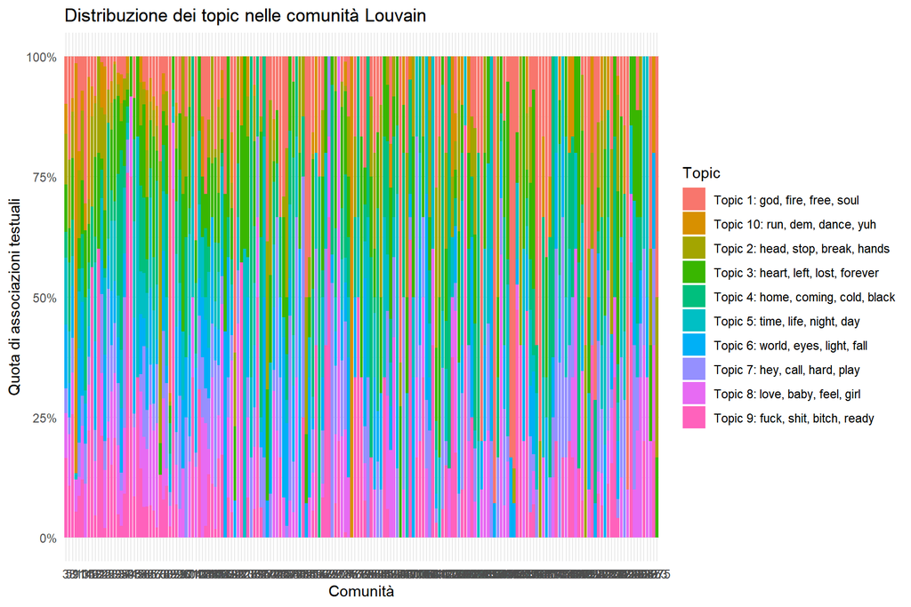

```r
if (nrow(community_topic_summary) > 0) {

  ggplot(
    community_topic_summary,
    aes(
      x = factor(community),
      y = topic_share,
      fill = topic_label
    )
  ) +
    geom_col() +
    scale_y_continuous(
      labels = percent_format()
    ) +
    theme_minimal() +
    labs(
      title = "Distribuzione dei topic nelle comunità Louvain",
      x = "Comunità",
      y = "Quota di associazioni testuali",
      fill = "Topic"
    )

} else {

  cat(
    "Nessuna comunità possiede almeno cinque documenti distinti.\n"
  )
}
```

### 6.2.1 Visualizzazione delle principali comunità

Il grafico precedente comprende tutte le community associate ad almeno cinque documenti distinti. Sebbene ciò permetta di mantenere un’elevata copertura dei dati, il numero di comunità rende difficile leggere le etichette sull’asse delle ascisse e confrontare visivamente le rispettive distribuzioni.

Come approfondimento vengono quindi rappresentate separatamente le 20 community associate al maggior numero di documenti distinti. La selezione riguarda esclusivamente la visualizzazione e non modifica i dati utilizzati nelle analisi precedenti.

```r
# Seleziono le 20 community con il maggior numero di documenti distinti
top_community_counts <- community_document_counts %>%
  slice_max(
    order_by = community_documents,
    n = 20,
    with_ties = FALSE
  ) %>%
  arrange(desc(community_documents))

# Mantengo nel grafico soltanto le community selezionate
community_topic_plot <- community_topic_summary %>%
  inner_join(
    top_community_counts,
    by = "community"
  )

# Ordino numericamente i topic:
# Topic 1, Topic 2, ..., Topic 10
ordered_topic_labels <- community_topic_plot %>%
  distinct(topic_label) %>%
  mutate(
    topic_number = parse_number(as.character(topic_label))
  ) %>%
  arrange(topic_number) %>%
  pull(topic_label)

# Creo etichette compatte e ordino le community
# dalla più rappresentata alla meno rappresentata
community_topic_plot <- community_topic_plot %>%
  mutate(
    topic_label = factor(
      topic_label,
      levels = ordered_topic_labels
    ),
    community_label = factor(
      paste0("C", as.character(community)),
      levels = paste0(
        "C",
        as.character(top_community_counts$community)
      )
    )
  )
```

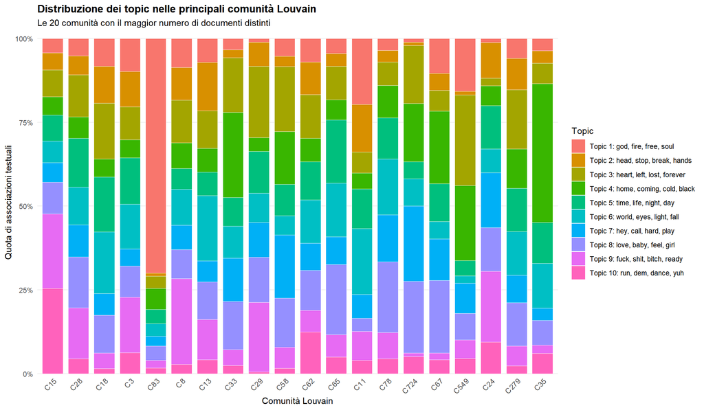

```r
if (nrow(community_topic_plot) > 0) {

  ggplot(
    community_topic_plot,
    aes(
      x = community_label,
      y = topic_share,
      fill = topic_label
    )
  ) +
    geom_col(
      width = 0.8,
      color = "white",
      linewidth = 0.15
    ) +
    scale_y_continuous(
      labels = percent_format(accuracy = 1),
      breaks = seq(0, 1, by = 0.25),
      expand = expansion(mult = c(0, 0.02))
    ) +
    labs(
      title = "Distribuzione dei topic nelle principali comunità Louvain",
      subtitle = paste(
        "Le 20 comunità con il maggior numero",
        "di documenti distinti"
      ),
      x = "Comunità Louvain",
      y = "Quota di associazioni testuali",
      fill = "Topic"
    ) +
    theme_minimal() +
    theme(
      axis.text.x = element_text(
        angle = 45,
        hjust = 1,
        vjust = 1,
        size = 9
      ),
      panel.grid.major.x = element_blank(),
      panel.grid.minor = element_blank(),
      legend.position = "right",
      plot.title = element_text(
        face = "bold"
      )
    )

} else {

  cat(
    "Non sono disponibili community sufficientemente rappresentate.\n"
  )
}
```

Le variabili testuali vengono riassunte per artista. Vengono considerati nelle analisi di correlazione soltanto gli artisti associati ad almeno due brani, in modo da evitare che un singolo testo rappresenti l’intera produzione osservata di un artista.

```r
artist_text_summary <- integrated_df %>%
  group_by(
    artist_network_name
  ) %>%
  summarise(
    matched_songs = n_distinct(doc_id),

    mean_popularity = mean(
      popularity,
      na.rm = TRUE
    ),

    mean_dominant_confidence = mean(
      dominant_gamma,
      na.rm = TRUE
    ),

    mean_technology_proxy = if (
      all(is.na(technology_proxy_gamma))
    ) {
      NA_real_
    } else {
      mean(
        technology_proxy_gamma,
        na.rm = TRUE
      )
    },

    weighted_degree = first(
      weighted_degree
    ),

    core_betweenness = first(
      core_betweenness
    ),

    pagerank = first(
      pagerank
    ),

    community = first(
      community
    ),

    .groups = "drop"
  ) %>%
  filter(
    matched_songs >= 2
  )

kable(
  head(
    artist_text_summary %>%
      arrange(
        desc(matched_songs)
      ),
    20
  ),
  digits = 5,
  caption = "Artisti con il maggior numero di testi allineati"
)
```

Artisti con il maggior numero di testi allineati

| artist_network_name | matched_songs | mean_popularity | mean_dominant_confidence | mean_technology_proxy | weighted_degree | core_betweenness | pagerank | community |
| --- | --- | --- | --- | --- | --- | --- | --- | --- |
| george jones | 138 | 17.07246 | 0.21536 | 0.07643 | 72 | 0.00064 | 0.00044 | 58 |
| glee cast | 123 | 41.83740 | 0.28331 | 0.07739 | 32 | 0.04970 | 0.00016 | 33 |
| the beatles | 97 | 61.49485 | 0.25519 | 0.07499 | 1 | NA | 0.00005 | 724 |
| hank williams | 89 | 19.06742 | 0.23356 | 0.07264 | 108 | 0.00000 | 0.00014 | 549 |
| vybz kartel | 86 | 23.61628 | 0.55923 | 0.04861 | 51 | 0.00870 | 0.00043 | 15 |
| linkin park | 78 | 55.74359 | 0.25823 | 0.13453 | 27 | 0.00000 | 0.00030 | 8 |
| scooter | 68 | 25.41176 | 0.26037 | 0.11668 | 17 | 0.00198 | 0.00017 | 24 |
| chris tomlin | 62 | 43.30645 | 0.37181 | 0.05882 | 51 | 0.01461 | 0.00037 | 83 |
| hillsong worship | 61 | 45.27869 | 0.40448 | 0.06104 | 104 | 0.00256 | 0.00046 | 83 |
| onerepublic | 56 | 56.05357 | 0.24886 | 0.08665 | 18 | 0.00092 | 0.00012 | 28 |
| elvis presley | 50 | 54.24000 | 0.25132 | 0.07928 | 4 | NA | 0.00005 | 67 |
| xxxtentacion | 49 | 63.97959 | 0.30892 | 0.11474 | 48 | 0.00023 | 0.00035 | 15 |
| the prodigy | 39 | 38.25641 | 0.38310 | 0.17729 | 21 | 0.00640 | 0.00022 | 3 |
| andrew lloyd webber | 38 | 24.92105 | 0.20086 | 0.08999 | 158 | 0.05932 | 0.00072 | 141 |
| tove lo | 36 | 51.08333 | 0.25264 | 0.08996 | 41 | 0.00353 | 0.00030 | 28 |
| drifting cowboys | 35 | 28.14286 | 0.23535 | 0.06706 | 104 | 0.00000 | 0.00012 | 549 |
| rustage | 34 | 42.32353 | 0.25496 | 0.22188 | 92 | 0.00004 | 0.00037 | 73 |
| adele | 33 | 67.45455 | 0.24919 | 0.07515 | 2 | NA | 0.00004 | 62 |
| john mayer | 33 | 63.96970 | 0.22038 | 0.07975 | 5 | NA | 0.00006 | 8 |
| five finger death punch | 31 | 53.93548 | 0.25229 | 0.11445 | 4 | NA | 0.00003 | 567 |

## 6.4 Centralità e temi tecnologici

Le correlazioni di Spearman vengono calcolate soltanto se nel vocabolario sono presenti parole del dizionario tecnologico e sono disponibili almeno dieci artisti con dati completi. Spearman è usato perché le centralità hanno distribuzioni asimmetriche. Valori vicini a zero indicano assenza di una relazione monotona rilevante.

```r
enough_technology_data <-
  technology_words_available &&
  sum(!is.na(artist_text_summary$mean_technology_proxy)) >= 10

if (enough_technology_data) {
  technology_correlations <- tibble(
    metrica = c("Strength", "Core betweenness", "PageRank", "Popolarità media"),
    correlazione_spearman = c(
      cor(
        artist_text_summary$mean_technology_proxy,
        artist_text_summary$weighted_degree,
        method = "spearman", use = "complete.obs"
      ),
      cor(
        artist_text_summary$mean_technology_proxy,
        artist_text_summary$core_betweenness,
        method = "spearman", use = "complete.obs"
      ),
      cor(
        artist_text_summary$mean_technology_proxy,
        artist_text_summary$pagerank,
        method = "spearman", use = "complete.obs"
      ),
      cor(
        artist_text_summary$mean_technology_proxy,
        artist_text_summary$mean_popularity,
        method = "spearman", use = "complete.obs"
      )
    )
  )

  print(kable(
    technology_correlations,
    digits = 4,
    caption = "Correlazioni di Spearman con il proxy tecnologico"
  ))
} else {
  cat("Dati insufficienti per calcolare le correlazioni con il proxy tecnologico.\n")
}
```

```
##
##
## Table: Correlazioni di Spearman con il proxy tecnologico
##
## |metrica          | correlazione_spearman|
## |:----------------|---------------------:|
## |Strength         |               -0.0343|
## |Core betweenness |               -0.0896|
## |PageRank         |                0.0267|
## |Popolarità media |                0.0567|
```

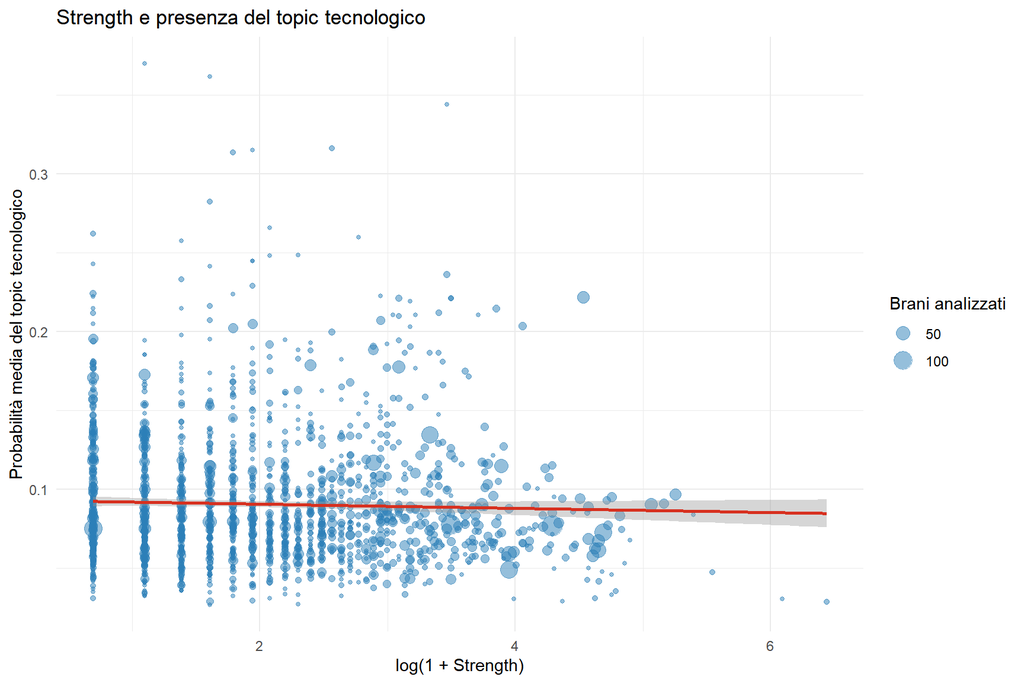

```r
if (
  technology_words_available &&
  sum(!is.na(artist_text_summary$mean_technology_proxy)) >= 10
) {

  ggplot(
    artist_text_summary,
    aes(
      x = log1p(weighted_degree),
      y = mean_technology_proxy
    )
  ) +
    geom_point(
      aes(
        size = matched_songs
      ),
      alpha = 0.50,
      color = "#2C7FB8"
    ) +
    geom_smooth(
      method = "lm",
      se = TRUE,
      color = "#D7301F"
    ) +
    theme_minimal() +
    labs(
      title = "Strength e presenza del topic tecnologico",
      x = "log(1 + Strength)",
      y = "Probabilità media del topic tecnologico",
      size = "Brani analizzati"
    )
}
```

## 6.5 Topic, popolarità e caratteristiche acustiche

Le medie seguenti descrivono le differenze osservate fra i topic. Non sono test causali e non dimostrano che un contenuto produca maggiore popolarità.

```r
topic_audio_popularity <- song_topics %>%
  filter(
    !is.na(topic_label)
  ) %>%
  group_by(
    topic_label
  ) %>%
  summarise(
    songs = n_distinct(track_id),

    mean_popularity = mean(
      popularity,
      na.rm = TRUE
    ),

    median_popularity = median(
      popularity,
      na.rm = TRUE
    ),

    mean_danceability = mean(
      danceability,
      na.rm = TRUE
    ),

    mean_energy = mean(
      energy,
      na.rm = TRUE
    ),

    mean_acousticness = mean(
      acousticness,
      na.rm = TRUE
    ),

    mean_valence = mean(
      valence,
      na.rm = TRUE
    ),

    .groups = "drop"
  ) %>%
  arrange(
    desc(mean_popularity)
  )

kable(
  topic_audio_popularity,
  digits = 3,
  caption = "Popolarità e caratteristiche acustiche per topic dominante"
)
```

Popolarità e caratteristiche acustiche per topic dominante

| topic_label | songs | mean_popularity | median_popularity | mean_danceability | mean_energy | mean_acousticness | mean_valence |
| --- | --- | --- | --- | --- | --- | --- | --- |
| Topic 5: time, life, night, day | 1772 | 45.301 | 50.0 | 0.554 | 0.674 | 0.230 | 0.455 |
| Topic 8: love, baby, feel, girl | 1809 | 45.074 | 51.0 | 0.585 | 0.620 | 0.294 | 0.510 |
| Topic 3: heart, left, lost, forever | 2149 | 44.303 | 49.0 | 0.522 | 0.644 | 0.270 | 0.423 |
| Topic 6: world, eyes, light, fall | 1922 | 43.767 | 48.0 | 0.513 | 0.681 | 0.206 | 0.384 |
| Topic 9: fuck, shit, bitch, ready | 1709 | 43.712 | 50.0 | 0.662 | 0.697 | 0.180 | 0.544 |
| Topic 7: hey, call, hard, play | 1667 | 41.331 | 44.0 | 0.564 | 0.659 | 0.271 | 0.546 |
| Topic 10: run, dem, dance, yuh | 905 | 38.557 | 33.0 | 0.668 | 0.708 | 0.214 | 0.605 |
| Topic 2: head, stop, break, hands | 1827 | 38.099 | 32.0 | 0.484 | 0.807 | 0.109 | 0.408 |
| Topic 4: home, coming, cold, black | 1802 | 35.829 | 34.5 | 0.530 | 0.577 | 0.377 | 0.476 |
| Topic 1: god, fire, free, soul | 2619 | 34.825 | 29.0 | 0.423 | 0.769 | 0.137 | 0.318 |

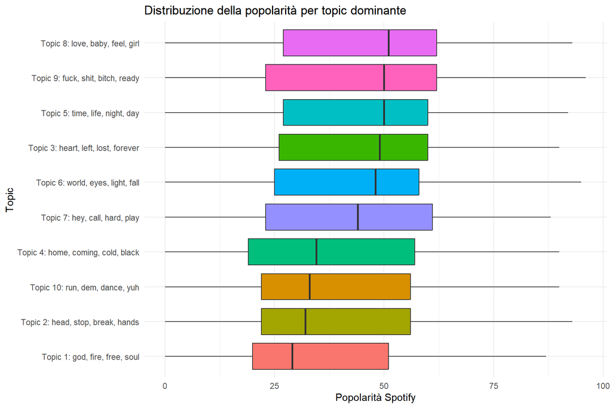

```r
ggplot(
  song_topics %>%
    filter(
      !is.na(topic_label)
    ),
  aes(
    x = reorder(
      topic_label,
      popularity,
      FUN = median,
      na.rm = TRUE
    ),
    y = popularity,
    fill = topic_label
  )
) +
  geom_boxplot(
    show.legend = FALSE,
    outlier.alpha = 0.30
  ) +
  coord_flip() +
  theme_minimal() +
  labs(
    title = "Distribuzione della popolarità per topic dominante",
    x = "Topic",
    y = "Popolarità Spotify"
  )
```

## 6.6 Modello statistico esplorativo

Il modello mette in relazione la popolarità con il proxy testuale, le centralità medie degli artisti accreditati e le caratteristiche acustiche. Le centralità vengono trasformate con `log1p()` per ridurne l’asimmetria.

La `core_betweenness` è disponibile soltanto per il nucleo di 2.500 artisti. Di conseguenza, `drop_na()` limita la regressione ai brani con informazioni complete e il campione finale non rappresenta tutti i testi abbinati.

```r
model_df <- integrated_df %>%
  group_by(doc_id) %>%
  summarise(
    popularity = first(popularity),
    technology_proxy_gamma = first(technology_proxy_gamma),
    log_strength = log1p(mean(weighted_degree, na.rm = TRUE)),
    log_core_betweenness = log1p(mean(core_betweenness, na.rm = TRUE)),
    log_pagerank = log1p(mean(pagerank, na.rm = TRUE)),
    danceability = first(danceability),
    energy = first(energy),
    acousticness = first(acousticness),
    valence = first(valence),
    .groups = "drop"
  ) %>%
  drop_na()

number_of_complete_observations <- nrow(model_df)

kable(
  tibble(
    indicatore = "Osservazioni complete",
    valore = number_of_complete_observations
  ),
  caption = "Numerosità del dataset usato nella regressione"
)
```

Numerosità del dataset usato nella regressione

| indicatore | valore |
| --- | --- |
| Osservazioni complete | 3919 |

```r
model_can_be_estimated <-
  technology_words_available && number_of_complete_observations >= 60

if (model_can_be_estimated) {
  popularity_model <- lm(
    popularity ~ technology_proxy_gamma + log_strength +
      log_core_betweenness + log_pagerank + danceability +
      energy + acousticness + valence,
    data = model_df
  )

  # print() evita che l'output scompaia quando il modello è dentro if
  print(summary(popularity_model))

  model_r_squared <- summary(popularity_model)$r.squared
  model_adjusted_r_squared <- summary(popularity_model)$adj.r.squared
} else {
  popularity_model <- NULL
  model_r_squared <- NA_real_
  model_adjusted_r_squared <- NA_real_
  cat("Il modello non viene stimato: dati completi insufficienti.\n")
}
```

```
##
## Call:
## lm(formula = popularity ~ technology_proxy_gamma + log_strength +
##     log_core_betweenness + log_pagerank + danceability + energy +
##     acousticness + valence, data = model_df)
##
## Residuals:
##     Min      1Q  Median      3Q     Max
## -54.948 -16.054   3.153  15.666  52.993
##
## Coefficients:
##                        Estimate Std. Error t value Pr(>|t|)
## (Intercept)              51.955      3.268  15.897  < 2e-16 ***
## technology_proxy_gamma    6.574      5.593   1.175  0.23990
## log_strength             -3.962      0.844  -4.694 2.77e-06 ***
## log_core_betweenness     69.718     26.925   2.589  0.00965 **
## log_pagerank           6056.131   4302.993   1.407  0.15938
## danceability             18.572      2.716   6.837 9.31e-12 ***
## energy                   -1.316      2.445  -0.538  0.59056
## acousticness            -10.843      1.845  -5.878 4.50e-09 ***
## valence                 -13.474      1.818  -7.411 1.53e-13 ***
## ---
## Signif. codes:  0 '***' 0.001 '**' 0.01 '*' 0.05 '.' 0.1 ' ' 1
##
## Residual standard error: 22.03 on 3910 degrees of freedom
## Multiple R-squared:  0.06237,    Adjusted R-squared:  0.06045
## F-statistic: 32.51 on 8 and 3910 DF,  p-value: < 2.2e-16
```

# 7. Discussione dei risultati

## 7.1 Struttura della rete delle collaborazioni

## 7.1 Struttura della rete delle collaborazioni

La rete comprende 19.655 artisti con almeno una co-occorrenza nei crediti e 38.670 relazioni. Non include quindi gli artisti osservati soltanto in brani solisti.

La Strength più alta appartiene a Pritam (627), seguito da Wolfgang Amadeus Mozart (557) e Arijit Singh (441). Questo risultato mostra anche un limite importante: i crediti Spotify collegano non soltanto featuring contemporanei, ma anche compositori, interpreti, orchestre e altri soggetti accreditati.

Le community principali mostrano profili coerenti con generi o mercati musicali. Per esempio, la community 15 comprende J Balvin, Bad Bunny e Daddy Yankee; la community 28 comprende David Guetta, Tiësto e Martin Garrix; la community 126 raccoglie soprattutto musica classica. Le community sono però gruppi strutturali prodotti da Louvain e non etichette di genere già validate.

## 7.2 Interpretazione dei topic

## 7.2 Interpretazione dei topic

La DTM contiene 18.181 documenti e 12.806 termini. Tra i valori provati è stato selezionato $k = 10$, con perplexity pari a 1659,56.

La perplexity diminuisce per tutti i candidati e raggiunge il minimo al limite superiore del confronto. Il risultato sostiene l’uso di 10 topic per questa analisi, ma non dimostra che 10 sia il numero ottimale in assoluto.

Le parole principali permettono una lettura indicativa: il Topic 1 richiama spiritualità, conflitto e morte; il Topic 3 perdita e dolore; il Topic 8 relazioni sentimentali; il Topic 9 lessico rap esplicito; il Topic 10 lessico dancehall/reggae. Le etichette basate sulle prime quattro parole restano descrittive e molti brani presentano una miscela di più topic.

## 7.3 Presenza dei temi tecnologici

## 7.3 Presenza dei temi tecnologici

Il Topic 2 assegna al dizionario tecnologico la massa beta più alta, pari a 0,006548. Il secondo valore è 0,005213 e il rapporto fra i due è soltanto 1,26.

Le parole più probabili del Topic 2 sono `head`, `stop`, `break` e `hands`, quindi non descrivono un tema tecnologico autonomo. Il risultato corretto è che il Topic 2 è relativamente più vicino al dizionario rispetto agli altri topic. Nel corpus non emerge invece una categoria latente chiaramente e principalmente dedicata a tecnologia, digitale o automazione.

Il confronto post hoc con il lessico digitale ha individuato il Topic 2 come quello maggiormente associato all’area tecnologica. La massa beta complessiva dei termini digitali è pari a 0.006548. Il risultato deve essere interpretato come associazione esplorativa, non come prova che tutti i brani appartenenti al topic trattino necessariamente la tecnologia.

## 7.4 Relazione fra rete, testi e popolarità

## 7.4 Relazione fra rete, testi e popolarità

Le correlazioni di Spearman fra il proxy tecnologico e le altre variabili sono tutte molto vicine a zero: −0,0343 con la Strength, −0,0896 con la `core_betweenness`, 0,0267 con PageRank e 0,0567 con la popolarità media. Nel campione non emerge quindi una relazione monotona sostanziale tra centralità dell’artista e vicinanza al topic relativamente più digitale.

La popolarità media varia fra i topic: il Topic 5 raggiunge 45,301, il Topic 8 raggiunge 45,074 e il Topic 1 raggiunge 34,825. Queste sono differenze descrittive; senza un confronto inferenziale non provano che il contenuto del topic determini la popolarità.

La regressione utilizza 3.919 osservazioni. Il modello produce un $R^2$ pari a 0,06237 e un $R^2$ corretto pari a 0,06045: spiega quindi soltanto circa il 6,24% della variabilità della popolarità. Anche se il test complessivo è statisticamente significativo, la capacità esplicativa rimane debole e non permette interpretazioni causali.

## 7.5 Limiti dell’analisi

I principali limiti sono:

1. Spotify e Genius non condividono un identificatore univoco; il matching finale copre il 22,98% delle chiavi Spotify de-duplicate.
2. Il matching esatto sulle chiavi normalizzate può perdere varianti grafiche e può creare qualche falso abbinamento.
3. Il campione manuale di 30 corrispondenze è un controllo qualitativo, non una stima formale dell’accuratezza.
4. La rete contiene co-occorrenze nei crediti e non soltanto featuring; esclude inoltre gli artisti presenti esclusivamente in brani solisti.
5. L’analisi testuale è limitata ai testi classificati come inglesi e disponibili su Genius.
6. Il numero di topic è il migliore fra i candidati provati, ma la perplexity non presenta un minimo interno.
7. LDA richiede interpretazione manuale e l’assegnazione dominante può semplificare eccessivamente brani composti da più topic.
8. Il dizionario tecnologico è applicato post hoc e produce un proxy relativo, non una classe certa.
9. La `core_betweenness` è calcolata soltanto su 2.500 artisti; la regressione usa quindi un sottoinsieme selezionato di 3.919 osservazioni complete.
10. Correlazioni e regressione descrivono associazioni e non relazioni causali.

# 8. Conclusioni

Il progetto ha integrato Network Science e Text Mining su 89.738 brani Spotify puliti e 18.411 corrispondenze con Genius. Il matching rate del 22,98% rende possibile un’analisi testuale ampia, ma limita le conclusioni al sottoinsieme di brani effettivamente allineato.

La prima domanda di ricerca riguardava il ruolo delle collaborazioni. La rete mostra una struttura fortemente eterogenea, con 19.655 artisti collegati da 38.670 relazioni. Strength, PageRank e `core_betweenness` descrivono aspetti diversi della posizione degli artisti. Le community individuano gruppi coerenti con mercati e generi, ma la presenza di compositori e orchestre dimostra che la rete rappresenta crediti condivisi e non esclusivamente featuring.

La seconda domanda riguardava i temi latenti e la presenza della tecnologia. LDA ha prodotto dieci insiemi lessicali interpretabili, ma il Topic 2, pur avendo la massa beta digitale più alta, non presenta parole principali chiaramente tecnologiche. Non emerge quindi un tema autonomo dedicato a digitale e automazione; emerge soltanto un topic relativamente più vicino al dizionario usato.

La terza domanda chiedeva se centralità e contenuti tecnologici fossero associati. Le correlazioni, comprese tra −0,0896 e 0,0567, sono sostanzialmente nulle. Anche la regressione ha una capacità esplicativa limitata, con (R^2 = 0,06237). Nel campione analizzato non si osserva dunque una relazione rilevante tra posizione nella rete e ricorso al proxy tecnologico, né una relazione forte con la popolarità.

Il risultato principale non è quindi la scoperta di un settore musicale già organizzato attorno alla tecnologia, ma l’assenza di evidenza sufficiente per sostenerlo con questi dati e con questo metodo. Un’estensione futura potrebbe usare identificatori ISRC per migliorare il matching e un dizionario validato, oppure un modello supervisionato, per distinguere riferimenti tecnologici reali da semplici occorrenze lessicali.

# 9. Dichiarazione sull’uso di strumenti di IA

ChatGPT è stato utilizzato come strumento di supporto per la revisione linguistica e il debugging di specifici blocchi di codice R, risolvere problemi di esecuzione e proporre soluzioni circoscritte:in particolare per la pulizia tramite espressioni regolari, la costruzione della Document-Term Matrix. I suggerimenti ricevuti sono stati letti, semplificati, adattati al progetto ed eseguiti dall’autore. La scelta dei dataset, le domande di ricerca, le soglie operative e l’interpretazione finale dei risultati restano responsabilità dell’autore.

# 10. Riproducibilità

Il seed fissato nel chunk iniziale rende riproducibili il campionamento training/test e l’addestramento LDA, compatibilmente con le versioni dei pacchetti. Durante la revisione è consigliabile usare `cache = FALSE` nel chunk `setup`, così ogni modifica viene realmente ricalcolata.